# 101camp0py

ch12

190324 20?2

# CAMP

[figure not shown]

> 比来时强

## WoW

> 不得不赞叹…

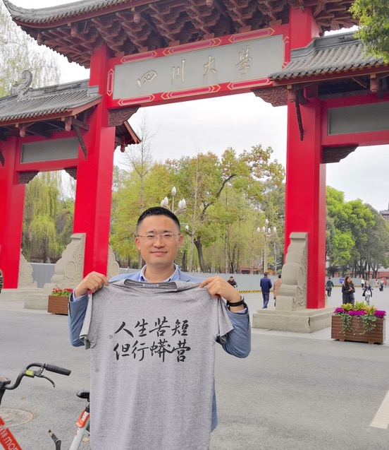

> @XiaoYanWork

big picture ;-)

## [#195](https://gitlab.com/101camp/py/issues/195#note_153542808)

> @tanchangde 唯一有录音团队

分享抓人技巧

## [#196](https://gitlab.com/101camp/py/issues/196#note_153543303)

> @Shuangma

功能亮点设计过程

## [#198](https://gitlab.com/101camp/py/issues/198#note_153543361)

> @doituself

起名困难症?

## [#199](https://gitlab.com/101camp/py/issues/199#note_153543463)

> @OMlalala

理财的核心科学机制?

## 嗯哼

[figure not shown]

# rhythm

## 节奏

> `ˈriT͟Həm`

## 习惯

> 而今固化否?

> > 42++

[figure not shown]

隐藏大坑

[figure not shown]

正确的画马流程

## MVPs

> 最小可用一切…

## Kaopulity

> 靠谱
- **K**eep
- **a**ll
- **o**f
- **p**rocesses
- **u**sabi**lity**

## EN

> 追查源文

## Google

> DuckDuckGo

## 5W1H

> 思考脚手架…

> > SMART / PDCA /…

## [zoom.us](https://zoom.us/download#client_4meeting)

> 例蠎交流
- d0 2042
- `404-101-4200`

## 玻璃花园

> C-C 式串门儿

## Activity

- commit
- commit-comments
- issue
- issue-comments
- slack

## IDD

> Issue Drive Develop

## IVL

> Issue Versions Logging

> > repo.+issue

## 嗯哼

## 自怼圈

> [2019 叒招新 ~ DebugUself -> DAMA](https://du.101.camp/2019-03/re-self-debuggers/)

> 一个清醒的选择沉迷在持续进步的自学型社区.

> > 1042元/年

[figure not shown]

# learn learn

## 知行

> 合一

## 如何提问?

> 能技

```
能使
    目标对象
        就
            指定命题
        产生
    科学兴趣的
技术
```

## f2f

> Face 2 Face

> > 面基

## 残念

> 未尽的嗯哼…

## [提问的智慧](https://github.com/DebugUself/How-To-Ask-Questions-The-Smart-Way/blob/master/README-zh_CN.md)

> 作业?

## 蠎周刊

> 自主嗯哼

> > ~=周报

## 新业书

> ~ 转职手册共创

## 作品

> 刚刚开始的 MVP

> > 去哪儿继续?

## [自怼圈](https://du.101.camp/2019-03/re-self-debuggers/)

> 54周蟒营式被自学

> 一个清醒的选择沉迷在持续进步的自学型社区.

> > 1042元/年

## 嗯哼

[figure not shown]

askdama@googlegroups.com

## 资源池

- 101camp@googlegroups.com
- 101.camp
- www.101.camp
- py.101.camp
- wiki.101.camp
- du.101.camp
- du.101.camp/duw
- …
- (?) pow.101.camp

# (￣▽￣)

## 101camp1py

> 蟒营: Python 入门正式班

[figure not shown]

## 190401前

> 2046元/人

> > 原价->4200元/人

## 190401后

> 2420元/人

> > 复读->2100元/人

## 推荐

> 优惠码 -> 老学员报名邮箱

> > 内推价-> 2178元/人

> 返现 <- 200元/人

## 转发海报

> slides.101.camp/img/101camp1py_sposter.jpeg

[figure not shown]

## URI

> slides.101.camp/ch12py101camp.html

## 是也乎

- 190324 DAMA pub.
- 190323 DAMA ++DUr
- 190320 DAMA ++BGM
- 190319 DAMA init.

## KM

[figure not shown]

知识螺旋

## GFM

> [GitLab Flavored Markdown](https://gitlab.com/help/user/markdown.md)

## 提问

> +5 为什么?

## 5W1H

> 框架…

## VCS

[版本管理](http://s5.zoomquiet.top/080730-cpc-SVN-Trac-KM/index.html)

[figure not shown]

嗯哼

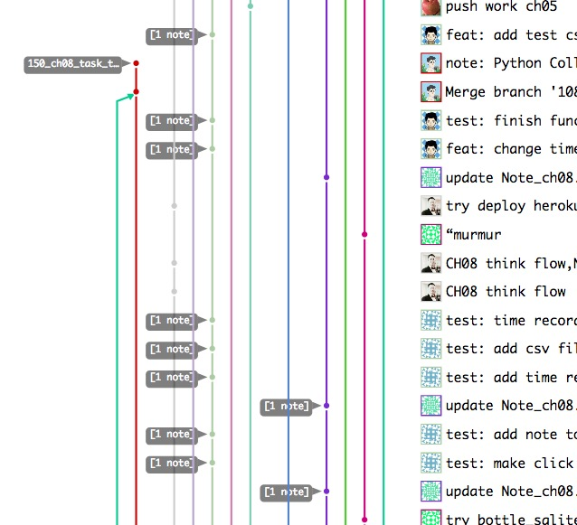

[figure not shown]

## pyenv

> Python 本地环境

## virtualenv

> [怎么才能放飞自我的玩儿Python · Yixuan](https://yixuan.li/geek/2018/07/31/pyenvVirtualenv/)

## WoW

> 不得不赞叹…

[figure not shown]

## 依赖?

> 节奏习惯的惯性…

## 以及

> 环境的被动拉动

[自学是门手艺](https://github.com/selfteaching/the-craft-of-selfteaching)

- the-craft-of-selfteaching
  - One has no future if one couldn’t teach themself.

## [#166](https://gitlab.com/101camp/py/issues/166)

> @chenmingio

[共创]“蟒营是什么?” 文案收集

## [I/O](http://io.101.camp/)

> io.101.camp